# Wine Reviews

### 首先，将文件存入数组中，便于后续处理：

```python
import os

def file_filter(f):
        if f[-4:] in ['.csv']:
            return True
        else:
            return False

def get_file_list(dir_):
    lists = os.listdir(dir_)
    lists = list(filter(file_filter, lists))
    return lists

file_path_arr = get_file_list(os.path.abspath(os.curdir))
print(file_path_arr)
```

```
['winemag-data-130k-v2.csv', 'winemag-data_first150k.csv']
```

### 查看数据的属性：

```python
import pandas as pd
import numpy as np

whole_data = []
for current_file in file_path_arr:
        whole_data.append(pd.read_csv(current_file, low_memory=False))
# print(whole_data[0].dtypes)
# print(whole_data[1].dtypes)
```

```python
attributes_130 = whole_data[0].columns
attributes_130 = np.array(attributes_130, dtype=object)
print(attributes_130)
attributes_150 = whole_data[1].columns
attributes_150 = np.array(attributes_150, dtype=object)
print(attributes_150)
```

```
['Unnamed: 0' 'country' 'description' 'designation' 'points' 'price'
 'province' 'region_1' 'region_2' 'taster_name' 'taster_twitter_handle'
 'title' 'variety' 'winery']
['Unnamed: 0' 'country' 'description' 'designation' 'points' 'price'
 'province' 'region_1' 'region_2' 'variety' 'winery']
```

```python
whole_data[0].isna().sum()
```

```
Unnamed: 0                   0
country                     63
description                  0
designation              37465
points                       0
price                     8996
province                    63
region_1                 21247
region_2                 79460
taster_name              26244
taster_twitter_handle    31213
title                        0
variety                      1
winery                       0
dtype: int64
```

```python
whole_data[1].isna().sum()
```

```
Unnamed: 0         0
country            5
description        0
designation    45735
points             0
price          13695
province           5
region_1       25060
region_2       89977
variety            0
winery             0
dtype: int64
```

可以看到，两个文件的属性名称大部分都是相同的，除了winemag-data-130-v2.csv中多出taster_name，taster_twitter_handle以及title，

其余相同的属性包括：['Unnamed: 0' 'country' 'description' 'designation' 'points' 'price' 'province' 'region_1' 'region_2' 'variety' 'winery']

Unnamed: 0：行号，无缺失值；

country：The country that the wine is from（葡萄酒的原产国），为标称属性，含缺失值；

description：对该酒的评价，为标称属性，无缺失值；

designation：The vineyard within the winery where the grapes that made the wine are from（酿酒厂内的葡萄园，酿制葡萄酒的葡萄的来源），为标称属性，含缺失值；

points：The number of points WineEnthusiast rated the wine on a scale of 1-100 (though they say they only post reviews for wines that score >=80)，为数值属性，无缺失值；

price：The cost for a bottle of the wine，为数值属性，含缺失值；

province：The province or state that the wine is from（出产葡萄酒的省或州），为标称属性，含缺失值；

region_1：The wine growing area in a province or state (ie Napa)（一个省或州的葡萄酒产区(如纳帕)），为标称属性，含缺失值；

region_2：Sometimes there are more specific regions specified within a wine growing area (ie Rutherford inside the Napa Valley), but this value can sometimes be blank（有时在葡萄酒的生长区域内会指定更特定的区域(如纳帕谷内的卢瑟福)，但这个值有时可以为空），为标称属性，含缺失值；

variety：The type of grapes used to make the wine (ie Pinot Noir)（用来酿酒的葡萄品种(如黑比诺)），为标称属性，含缺失值；

winery：酒庄，为标称属性，无缺失值；

taster_name：评价者的姓名，为标称属性，含缺失值；

taster_twitter_handle：评价者的推特地址，为标称属性，含缺失值；

title：The title of the wine review, which often contains the vintage if you're interested in extracting that feature（葡萄酒评论的标题，如果你有兴趣提取这一特征，通常会包含年份），为标称属性，无缺失值；

### 1~2.country& province& region_1& region_2& winery属性的处理，为标称属性。

这些属性都与葡萄酒的产地有关，分别是葡萄酒的原产国、葡萄酒的原产省/州、省/州中的产区、更加特定的区域、酒庄。

从上述的信息我们可以知道，这些有地理性质的属性，除了designation，其他的属性粒度从大到小排列。

值得一提的是，variety和designation或许存在一些关系，但由于它们之间并非一一对应，因此在这里暂时不做处理；title包含年份，同时也包含酒庄信息，与winery一一对应，其次，title中的括号内包含region_1的信息，可以用于补充region_1的缺失值。

因此，若大粒度的信息有所缺失，我们可以通过对应的小粒度信息进行补充，反之则不可以。

同时，可以发现的规律有：region_1/region_2的缺失程度比较高，若缺失region_1一定缺失region_2。

1. 将缺失部分剔除
2. 用最高频率值来填补缺失值
3. 通过属性的相关关系来填补缺失值
4. 通过数据对象之间的相似性来填补缺失值

综合上述四种补充缺失值的方式，以及数据本身的特征可以知道，地理信息对于本数据集非常重要，同时，最小粒度的参数并无缺失，但是，存在只有winery没有其余地理属性的情况，因此：

1. country& province& region_1& region_2都为空值，则删除该行数据（比如winery为Stone Castle时）；
2. 130k的数据用title补充region_1；
3. 若小粒度的信息存在，大粒度的信息缺失，那么利用小粒度的信息对大粒度的缺失值进行补充；

```
current file name:  winemag-data-130k-v2.csv
US                        54504
France                    22093
Italy                     19540
Spain                      6645
Portugal                   5691
Chile                      4472
Argentina                  3800
Austria                    3345
Australia                  2329
Germany                    2165
New Zealand                1419
South Africa               1401
Israel                      505
Greece                      466
Canada                      257
Hungary                     146
Bulgaria                    141
Romania                     120
Uruguay                     109
Turkey                       90
Slovenia                     87
Georgia                      86
England                      74
Croatia                      73
Mexico                       70
NaN                          63
Moldova                      59
Brazil                       52
Lebanon                      35
Morocco                      28
Peru                         16
Ukraine                      14
Serbia                       12
Macedonia                    12
Czech Republic               12
Cyprus                       11
India                         9
Switzerland                   7
Luxembourg                    6
Bosnia and Herzegovina        2
Armenia                       2
Egypt                         1
China                         1
Slovakia                      1
Name: country, dtype: int64
```

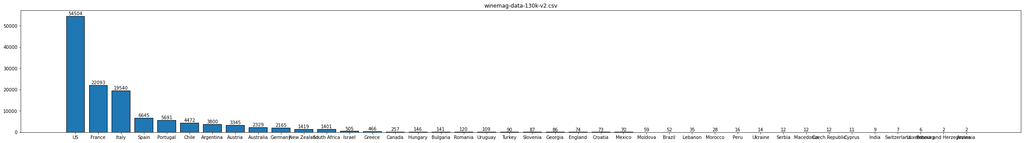

```python
# 分别给出以上几个属性的频数直方图

import matplotlib.pyplot as plt

def hist_bar(index, number, whole_data_):
        plt.figure(figsize=(40, 5))
        plt.title(file_path_arr[index])
        X = whole_data_[index][attribute].value_counts().index[:number]
        Y = whole_data_[index][attribute].value_counts().values[:number]
        plt.bar(X, Y, edgecolor='black')
        for x, y in zip(X, Y):
                plt.text(x, y, '%d' % y, ha='center', va='bottom')

def figure_by_attribute(file_index, attribute, whole_data_):
        print("current file name: ", file_path_arr[file_index])
        current_data = whole_data_[file_index]
        bin_data = current_data[attribute].value_counts(dropna = False)
        print(bin_data)
        hist_bar(file_index, 40, whole_data_)

attribute = attributes_150[1]
figure_by_attribute(0, attribute, whole_data)
```

```
current file name:  winemag-data_first150k.csv
US                        62397
Italy                     23478
France                    21098
Spain                      8268
Chile                      5816
Argentina                  5631
Portugal                   5322
Australia                  4957
New Zealand                3320
Austria                    3057
Germany                    2452
South Africa               2258
Greece                      884
Israel                      630
Hungary                     231
Canada                      196
Romania                     139
Slovenia                     94
Uruguay                      92
Croatia                      89
Bulgaria                     77
Moldova                      71
Mexico                       63
Turkey                       52
Georgia                      43
Lebanon                      37
Cyprus                       31
Brazil                       25
Macedonia                    16
Serbia                       14
Morocco                      12
Luxembourg                    9
England                       9
Lithuania                     8
India                         8
Czech Republic                6
NaN                           5
Ukraine                       5
Bosnia and Herzegovina        4
South Korea                   4
Switzerland                   4
China                         3
Slovakia                      3
Egypt                         3
Tunisia                       2
Montenegro                    2
Japan                         2
Albania                       2
US-France                     1
Name: country, dtype: int64
```

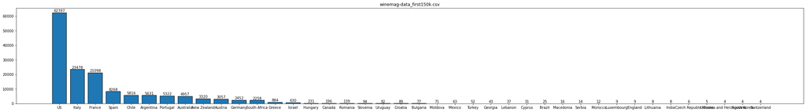

```python
figure_by_attribute(1, attribute, whole_data)
```

```
current file name:  winemag-data-130k-v2.csv
California          36247
Washington           8639
Bordeaux             5941
Tuscany              5897
Oregon               5373
                    ...
Vlootenburg             1
Imathia                 1
Paardeberg              1
Muscat of Patras        1
Canada Other            1
Name: province, Length: 426, dtype: int64
```

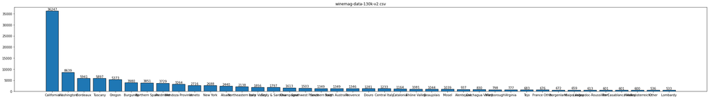

```python
attribute = attributes_150[6]
figure_by_attribute(0, attribute, whole_data)
```

```
current file name:  winemag-data_first150k.csv
California               44508
Washington                9750
Tuscany                   7281
Bordeaux                  6111
Northern Spain            4892
                         ...
Douro Superior               1
Vale Trentino                1
Ella Valley                  1
Pocerina                     1
Martinborough Terrace        1
Name: province, Length: 456, dtype: int64
```

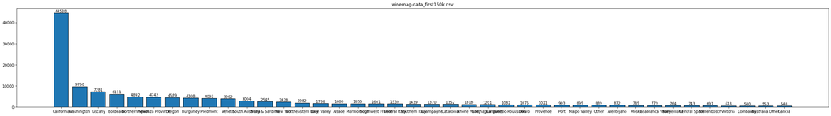

```python
figure_by_attribute(1, attribute, whole_data)
```

```
current file name:  winemag-data-130k-v2.csv
NaN                                      21247
Napa Valley                               4480
Columbia Valley (WA)                      4124
Russian River Valley                      3091
California                                2629
                                         ...
Dolcetto d'Alba Superiore                    1
Côtes du Roussillon Villages Caramany        1
Vin Pétillant                                1
Muscat de Saint-Jean de Minervois            1
Del Veneto                                   1
Name: region_1, Length: 1230, dtype: int64
```

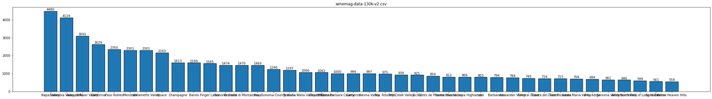

```python
attribute = attributes_150[7]
figure_by_attribute(0, attribute, whole_data)
```

```
current file name:  winemag-data_first150k.csv
NaN                                      25060
Napa Valley                               6209
Columbia Valley (WA)                      4975
Mendoza                                   3586
Russian River Valley                      3571
                                         ...
Côtes du Roussillon Villages Tautavel        1
Colli Tortonesi                              1
Mâcon-Mancey                                 1
Recioto della Valpolicella Valpantena        1
El Pomar District                            1
Name: region_1, Length: 1237, dtype: int64
```

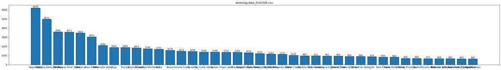

```python
figure_by_attribute(1, attribute, whole_data)
```

```
current file name:  winemag-data-130k-v2.csv
NaN                  79460
Central Coast        11065
Sonoma                9028
Columbia Valley       8103
Napa                  6814
Willamette Valley     3423
California Other      2663
Finger Lakes          1777
Sierra Foothills      1462
Napa-Sonoma           1169
Central Valley        1062
Southern Oregon        917
Oregon Other           727
Long Island            680
North Coast            584
Washington Other       534
South Coast            272
New York Other         231
Name: region_2, dtype: int64
```

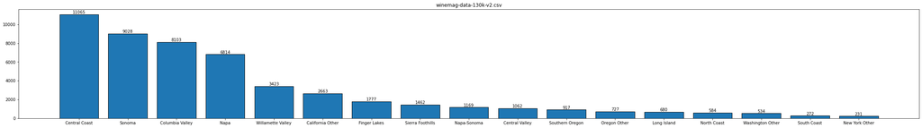

```python
attribute = attributes_150[8]
figure_by_attribute(0, attribute, whole_data)
```

```
current file name:  winemag-data_first150k.csv
NaN                        89977
Central Coast              13057
Sonoma                     11258
Columbia Valley             9157
Napa                        8801
California Other            3516
Willamette Valley           3181
Mendocino/Lake Counties     2389
Sierra Foothills            1660
Napa-Sonoma                 1645
Finger Lakes                1510
Central Valley              1115
Long Island                  771
Southern Oregon              662
Oregon Other                 661
North Coast                  632
Washington Other             593
South Coast                  198
New York Other               147
Name: region_2, dtype: int64
```

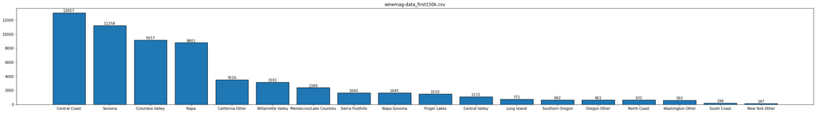

```python
figure_by_attribute(1, attribute, whole_data)
```

```
current file name:  winemag-data-130k-v2.csv
Wines & Winemakers         222
Testarossa                 218
DFJ Vinhos                 215
Williams Selyem            211
Louis Latour               199
                          ...
Molí dels Capellans          1
Domaine Borie de Maurel      1
Robert Losey                 1
Vinilo                       1
Bentley                      1
Name: winery, Length: 16757, dtype: int64
```

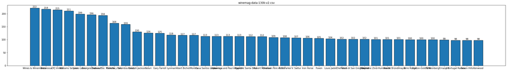

```python
attribute = attributes_150[10]
figure_by_attribute(0, attribute, whole_data)
```

```
current file name:  winemag-data_first150k.csv
Williams Selyem                  374
Testarossa                       274
DFJ Vinhos                       258
Chateau Ste. Michelle            225
Columbia Crest                   217
                                ...
Domaine de Camparine               1
Yemanueva                          1
Cantagallo                         1
Domaine Michel Thomas et Fils      1
Patrice Moreux                     1
Name: winery, Length: 14810, dtype: int64
```

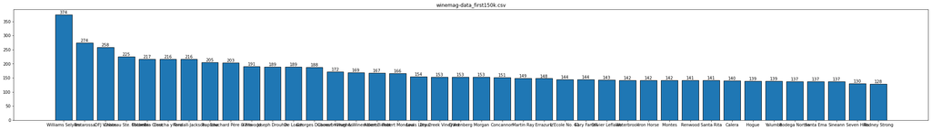

```python
figure_by_attribute(1, attribute, whole_data)
```

1.1 将缺失所有地理属性的数据删除

```python
# fist150k

print("current file name: ", file_path_arr[1])
current_data = whole_data[1]
attribute_1 = attributes_150[1]
print(attribute_1)
attribute_6 = attributes_150[6]
print(attribute_6)
attribute_7 = attributes_150[7]
print(attribute_7)
attribute_8 = attributes_150[8]
print(attribute_8)
attribute_10 = attributes_150[10]
print(attribute_10)
del_nan_0 = current_data.dropna(axis='index', how='all', subset=[attribute_1,attribute_6,attribute_7,attribute_8])

number = 40
```

```
current file name:  winemag-data_first150k.csv
country
province
region_1
region_2
winery
```

```python
current_data.isna().sum()
```

```
Unnamed: 0         0
country            5
description        0
designation    45735
points             0
price          13695
province           5
region_1       25060
region_2       89977
variety            0
winery             0
dtype: int64
```

```python
del_nan_0.isna().sum()
```

```
Unnamed: 0         0
country            0
description        0
designation    45735
points             0
price          13695
province           0
region_1       25055
region_2       89972
variety            0
winery             0
dtype: int64
```

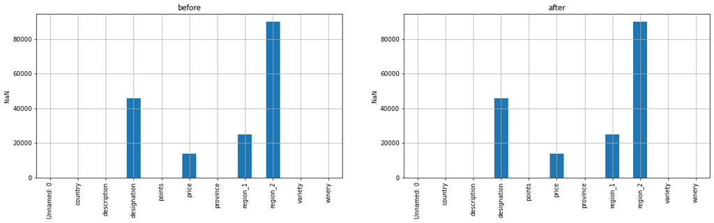

```python
plt.subplot(1,2,1)
current_data.isna().sum().plot(kind='bar',figsize=(20,5), grid=True, ylabel = "NaN", title="before")
plt.subplot(1,2,2)
del_nan_0.isna().sum().plot(kind='bar', grid=True, ylabel = "NaN", title="after")
```

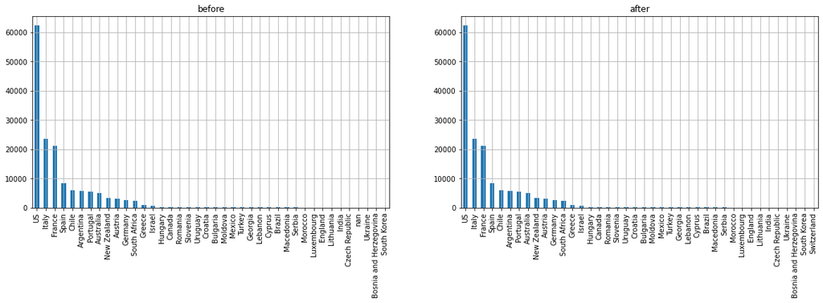

```python
plt.subplot(1,2,1)
current_data[attribute_1].value_counts(dropna = False)[:number].plot(kind='bar',figsize=(20,5), grid=True, title="before")
plt.subplot(1,2,2)
del_nan_0[attribute_1].value_counts(dropna = False)[:number].plot(kind='bar', grid=True, title="after")
```

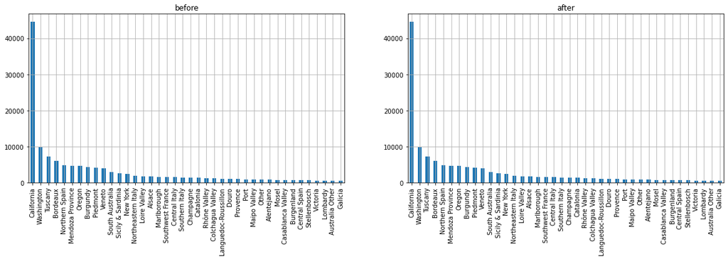

```python
plt.subplot(1,2,1)
current_data[attribute_6].value_counts(dropna = False)[:number].plot(kind='bar',figsize=(20,5), grid=True, title="before")
plt.subplot(1,2,2)
del_nan_0[attribute_6].value_counts(dropna = False)[:number].plot(kind='bar', grid=True, title="after")
```

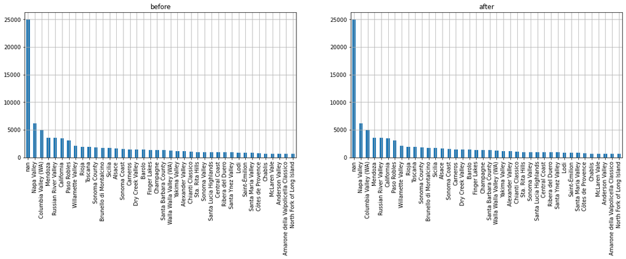

```python
plt.subplot(1,2,1)
current_data[attribute_7].value_counts(dropna = False)[:number].plot(kind='bar',figsize=(20,5), grid=True, title="before")
plt.subplot(1,2,2)
del_nan_0[attribute_7].value_counts(dropna = False)[:number].plot(kind='bar', grid=True, title="after")
```

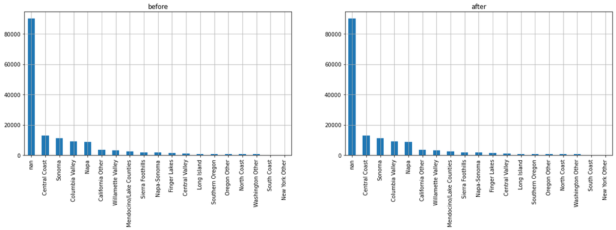

```python
plt.subplot(1,2,1)
current_data[attribute_8].value_counts(dropna = False)[:number].plot(kind='bar',figsize=(20,5), grid=True, title="before")
plt.subplot(1,2,2)
del_nan_0[attribute_8].value_counts(dropna = False)[:number].plot(kind='bar', grid=True, title="after")
```

```python
# 130k-v2

print("current file name: ", file_path_arr[0])
current_data = whole_data[0]
del_nan_1 = current_data.dropna(axis='index', how='all', subset=[attribute_1,attribute_6,attribute_7,attribute_8])

number = 40
```

```
current file name:  winemag-data-130k-v2.csv
```

```python
current_data.isna().sum()
```

```
Unnamed: 0                   0
country                     63
description                  0
designation              37465
points                       0
price                     8996
province                    63
region_1                 21247
region_2                 79460
taster_name              26244
taster_twitter_handle    31213
title                        0
variety                      1
winery                       0
dtype: int64
```

```python
del_nan_1.isna().sum()
```

```
Unnamed: 0                   0
country                      0
description                  0
designation              37454
points                       0
price                     8992
province                     0
region_1                 21184
region_2                 79397
taster_name              26244
taster_twitter_handle    31213
title                        0
variety                      1
winery                       0
dtype: int64
```

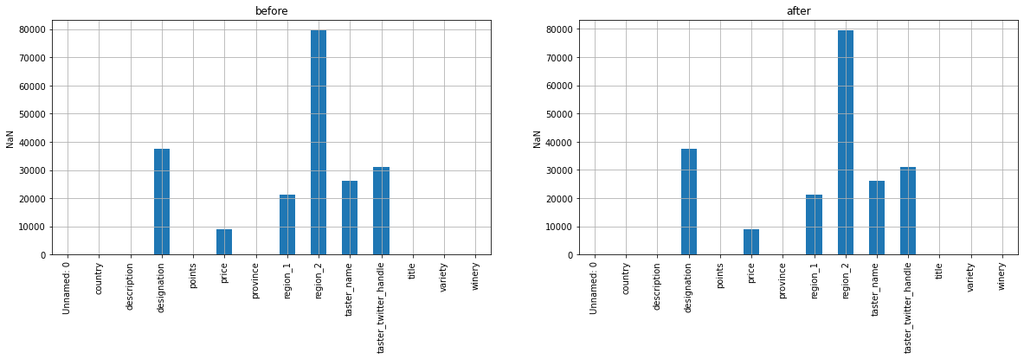

```python
plt.subplot(1,2,1)
current_data.isna().sum().plot(kind='bar',figsize=(20,5), grid=True, ylabel = "NaN", title="before")
plt.subplot(1,2,2)
del_nan_1.isna().sum().plot(kind='bar', grid=True, ylabel = "NaN", title="after")
```

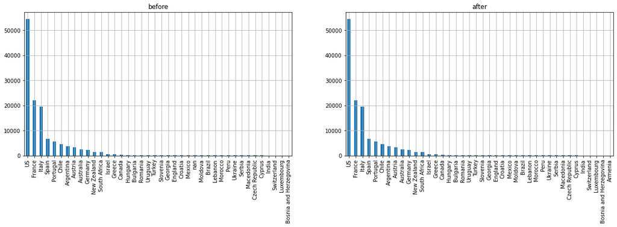

```python
plt.subplot(1,2,1)
current_data[attribute_1].value_counts(dropna = False)[:number].plot(kind='bar',figsize=(20,5), grid=True, title="before")
plt.subplot(1,2,2)
del_nan_1[attribute_1].value_counts(dropna = False)[:number].plot(kind='bar', grid=True, title="after")
```

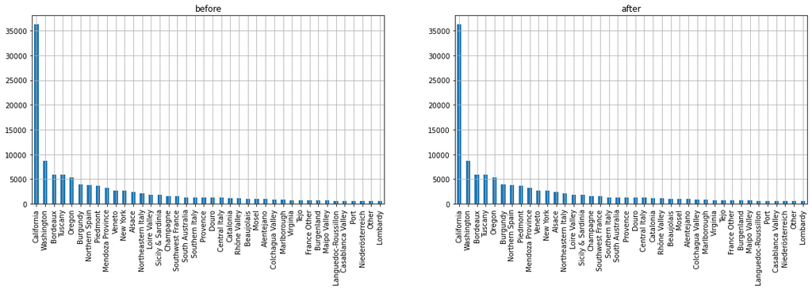

```python
plt.subplot(1,2,1)
current_data[attribute_6].value_counts(dropna = False)[:number].plot(kind='bar',figsize=(20,5), grid=True, title="before")
plt.subplot(1,2,2)
del_nan_1[attribute_6].value_counts(dropna = False)[:number].plot(kind='bar', grid=True, title="after")
```

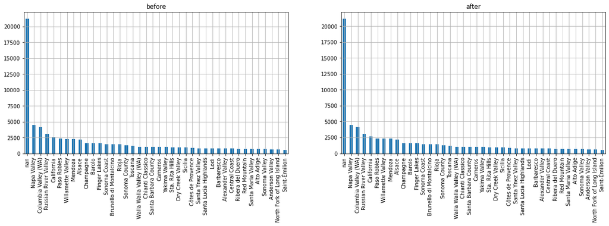

```python
plt.subplot(1,2,1)
current_data[attribute_7].value_counts(dropna = False)[:number].plot(kind='bar',figsize=(20,5), grid=True, title="before")
plt.subplot(1,2,2)
del_nan_1[attribute_7].value_counts(dropna = False)[:number].plot(kind='bar', grid=True, title="after")
```

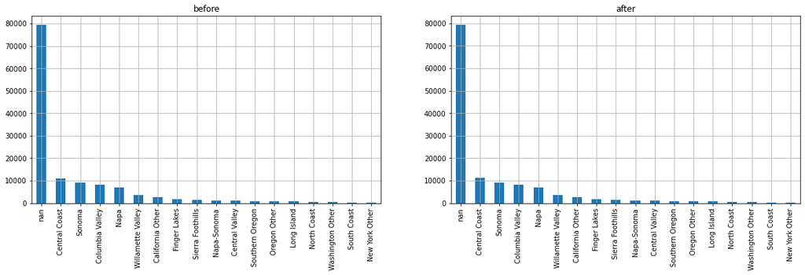

```python
plt.subplot(1,2,1)
current_data[attribute_8].value_counts(dropna = False)[:number].plot(kind='bar',figsize=(20,5), grid=True, title="before")
plt.subplot(1,2,2)
del_nan_1[attribute_8].value_counts(dropna = False)[:number].plot(kind='bar', grid=True, title="after")
```

可以看到，使用这个方法，150k和130k的缺失值数量发生了变化，将它们去掉缺失值后的数据进行保存。

```python
for current_file in file_path_arr:
    print("carrent file name: ", current_file)
    data = pd.read_csv(current_file, keep_default_na=False, low_memory=False)
    index_nan_by_country = data[data[attribute_1] == ''].index
    for i in index_nan_by_country:
        if data.loc[i, attribute_6] == '' and data.loc[i, attribute_7] == '' and data.loc[i, attribute_8] == '':
            data = data.drop(index = i)
    data.to_csv(current_file, index=False)
```

```
carrent file name:  winemag-data-130k-v2.csv
carrent file name:  winemag-data_first150k.csv
```

```python
whole_data_after_del = []
for current_file in file_path_arr:
        whole_data_after_del.append(pd.read_csv(current_file, low_memory=False))

current_data = whole_data_after_del[0]
current_data.isna().sum()
```

```
Unnamed: 0                   0
country                      0
description                  0
designation              37454
points                       0
price                     8992
province                     0
region_1                 21184
region_2                 79397
taster_name              26244
taster_twitter_handle    31213
title                        0
variety                      1
winery                       0
dtype: int64
```

```python
current_data = whole_data_after_del[1]
current_data.isna().sum()
```

```
Unnamed: 0         0
country            0
description        0
designation    45735
points             0
price          13695
province           0
region_1       25055
region_2       89972
variety            0
winery             0
dtype: int64
```

1.2 130k的数据：使用title补充region_1

```python
import re

def fill_region_1(file):
    data = pd.read_csv(file, keep_default_na=False, low_memory=False)
    index_nan = data[data[attribute_7] == ''].index
    for i in index_nan:
        title = data.loc[i, attributes_130[11]]
        region_1 = re.findall(r'[(](.*?)[)]', title)
        if region_1 != []:
            region_1 = region_1[0]
            data.loc[i, attribute_7] = region_1
        print(title)
        print(region_1)
    data.to_csv(file,index = False)
```

```python
fill_region_1(file_path_arr[0])
```

```
Quinta dos Avidagos 2011 Avidagos Red (Douro)
Douro
Heinz Eifel 2013 Shine Gewürztraminer (Rheinhessen)
Rheinhessen
Richard Böcking 2013 Devon Riesling (Mosel)
Mosel
Estampa 2011 Estate Viognier-Chardonnay (Colchagua Valley)
Colchagua Valley
Sundance 2011 Merlot (Maule Valley)
Maule Valley
Casa Silva 2008 Gran Reserva Petit Verdot (Colchagua Valley)
Colchagua Valley
Tres Palacios 2011 Reserve Pinot Noir (Maipo Valley)
Maipo Valley
Schmitt Söhne 2015 Riesling (Rheinhessen)
Rheinhessen
Adega Cooperativa do Cartaxo 2014 Bridão Touriga Nacional (Tejo)
Tejo
Aresti 2014 Special Release Reserva Carmenère (Rapel Valley)
Rapel Valley
P.J. Valckenberg 2015 Undone Dry Riesling (Rheinhessen)
Rheinhessen
Fuchs 2015 Grüner Veltliner (Burgenland)
Burgenland
Leyda 2015 Single Vineyard Falaris Hill Chardonnay (Leyda Valley)
Leyda Valley
Le Riche 2003 Cabernet Sauvignon Reserve Cabernet Sauvignon (Stellenbosch)
Stellenbosch
Camberley 2004 Philosophers' Stone Red (Stellenbosch)
Stellenbosch
Delheim 2001 Grand Reserve Cabernet Sauvignon (Simonsberg-Stellenbosch)
Simonsberg-Stellenbosch
Beaumont 2005 Hope Marguerite Chenin Blanc (Walker Bay)
Walker Bay
Weingut Liebfrauenstift 2014 Dry Riesling (Rheinhessen)
Rheinhessen
Herdade Grande 2014 Gerações Colheita Seleccionada Branco White (Alentejano)
Alentejano
Carl Graff 2014 Graacher Himmelreich Spätlese Riesling (Mosel)
Mosel
```

[output cut: 42314 more lines]

```
Hawke's Bay
Ara 2013 Single Estate Pinot Gris (Marlborough)
Marlborough
Dog Point 2012 Chardonnay (Marlborough)
Marlborough
Esk Valley 2011 Gimblett Gravels Merlot-Cabernet Sauvignon-Malbec Red (Hawke's Bay)
Hawke's Bay
Babich 2010 Irongate Red (Hawke's Bay)
Hawke's Bay
Caves Transmontanas 2006 Vértice Pinot Noir (Douro)
Douro
Dalton 2012 Oak Aged Cabernet Sauvignon (Galilee)
Galilee
Dr. H. Thanisch (Erben Müller-Burggraef) 2013 Brauneberger Juffer-Sonnenuhr Spätlese Riesling (Mosel)
Erben Müller-Burggraef
```

查看补充后的region_1数据：

```
current file name:  winemag-data-130k-v2.csv
Napa Valley                 4480
Columbia Valley (WA)        4124
Russian River Valley        3091
California                  2629
Paso Robles                 2350
                            ...
Breede River Valley            1
Côtes du Frontonnais           1
Southern Flinders Ranges       1
Vlootenburg                    1
Landes                         1
Name: region_1, Length: 1599, dtype: int64
```

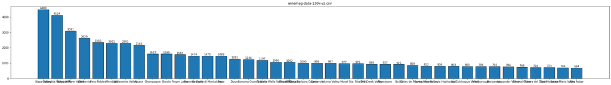

```python
whole_data_after_fill = []
for current_file in file_path_arr:
        whole_data_after_fill.append(pd.read_csv(current_file, low_memory=False))

attribute = attributes_150[7]
figure_by_attribute(0, attribute, whole_data_after_fill)
```

如下所示：输出处理后region_1缺失的行title，可以看到这些属于不规范的标题，没有用括号标注region_1信息。

```python
data = pd.read_csv(file_path_arr[0], keep_default_na=False, low_memory=False)
index_nan = data[data[attribute_7] == ''].index
print(index_nan)
for i in index_nan:
    title = data.loc[i, attributes_130[11]]
    print(title)
```

```
Int64Index([   261,    594,    622,    623,   1216,   1785,   2860,   4417,
              5672,   6023,
            ...
            122169, 122852, 124735, 124744, 124760, 126275, 127462, 127982,
            128464, 129238],
           dtype='int64', length=349)
Algodon 2008 Estate Blend Gran Reserva Red
Lavau 2015 La Decelle Red
Coiled 2009 Sidewinder Red
Coiled 2010 Black Mamba Red
Bava 2014 Piano Alto Barbera
Koenig Vineyards 2011 Ice Wine Riesling
Ste. Chapelle 2015 Special Harvest Riesling
Jorge Ordóñez & Co. 2016 Botani Old Vines Moscatel
Telaya 2014 Mourvèdre
Bitner 2012 Petit Verdot-Merlot Red
Medici Ermete NV Lambrusco I Quercioli Secco Lambrusco
Koenig Vineyards 2010 Ice Wine Riesling
3 Horse Ranch Vineyards 2011 Reserve Rosé
Sawtooth 2010 Skyline Red
Fujishin 2009 Bitner Vineyard Viognier
Domaine Joël Delaunay 2015 La Voûte Sauvignon Blanc
Castelvecchio 2015 Pinot Grigio
Koenig Vineyards 2006 Estate Vineyard Merlot
Château les Roques 2013
Vinovalie 2014 Tarani Malbec
Tango Reàl 2008 Gran Reserva Cabernet Sauvignon
Valentin Bianchi 2012 Enzo Bianchi Red
Domaine Maestracci 2015 Clos Reginu Red
3 Horse Ranch Vineyards 2008 Estate Grown Syrah-Mourvèdre
Sawtooth 2012 Estate Grown Pinot Gris
3 Horse Ranch Vineyards 2011 Reserve Syrah-Mourvèdre Red
Château du Cèdre 2011 Cedrus Malbec
Sawtooth 2011 Estate Grown Syrah
Valentin Bianchi 2008 Elsa Syrah
Château Bouissel 2010 Le Syrah de Bouissel Syrah
Williamson Vineyard 2012 Cabernet Sauvignon
Bitner 2013 Reserve Riesling
Valentin Bianchi 2009 Enzo Bianchi Red
Castelvecchio 2015 Sauvignon
```

[output cut: 300 more lines]

```
Alfredo Roca 2012 Reserva de Familia Malbec
Snake River 2010 Arena Valley Vineyard Riesling
3 Horse Ranch Vineyards 2014 Vivacious Viognier 76%/Roussanne 24% White
Hat Ranch 2014 Estate Grown Dry Moscato
Valentin Bianchi 2012 Particular Cabernet Sauvignon
3 Horse Ranch Vineyards 2013 Barrel Select Reserve Chardonnay
Château des Bachelards 2014 Grand Vin Gamay
Sawtooth 2010 Skyline Red
3 Horse Ranch Vineyards 2011 Reserve Rosé
3 Horse Ranch Vineyards 2011 Pinot Gris
3 Horse Ranch Vineyards 2016 Single Vineyard Pinot Gris
Lionel Osmin & Cie 2014 Ondenc
Valentin Bianchi 2011 Famiglia Bianchi Malbec
Cinder 2014 Syrah
Finca la Melonera 2014 Payoya Negra Red
```

通过查看源数据，我们可以观察到，这样的标题，年份后的英文字符就是region_1，因此再次对它们进行处理：

```python
def fill_region_1_second(file):
    data = pd.read_csv(file, keep_default_na=False, low_memory=False)
    index_nan = data[data[attribute_7] == ''].index
    for i in index_nan:
        title = data.loc[i, attributes_130[11]]
        year = re.findall(r'[1-2][0-9]{3}', title)
        print(title)
        print(year)
        if len(year) > 0:
            year = year[0]
            region_1 = title.split(year)[1][1:]
            print(region_1)
            data.loc[i, attribute_7] = region_1
    data.to_csv(file,index = False)
```

```python
fill_region_1_second(file_path_arr[0])
```

```
Algodon 2008 Estate Blend Gran Reserva Red
['2008']
Estate Blend Gran Reserva Red
Lavau 2015 La Decelle Red
['2015']
La Decelle Red
Coiled 2009 Sidewinder Red
['2009']
Sidewinder Red
Coiled 2010 Black Mamba Red
['2010']
Black Mamba Red
Bava 2014 Piano Alto Barbera
['2014']
Piano Alto Barbera
Koenig Vineyards 2011 Ice Wine Riesling
['2011']
Ice Wine Riesling
Ste. Chapelle 2015 Special Harvest Riesling
['2015']
Special Harvest Riesling
Jorge Ordóñez & Co. 2016 Botani Old Vines Moscatel
['2016']
Botani Old Vines Moscatel
Telaya 2014 Mourvèdre
['2014']
Mourvèdre
Bitner 2012 Petit Verdot-Merlot Red
['2012']
Petit Verdot-Merlot Red
Medici Ermete NV Lambrusco I Quercioli Secco Lambrusco
[]
Koenig Vineyards 2010 Ice Wine Riesling
['2010']
Ice Wine Riesling
3 Horse Ranch Vineyards 2011 Reserve Rosé
['2011']
Reserve Rosé
Sawtooth 2010 Skyline Red
['2010']
```

[output cut: 980 more lines]

```
3 Horse Ranch Vineyards 2016 Single Vineyard Pinot Gris
['2016']
Single Vineyard Pinot Gris
Lionel Osmin & Cie 2014 Ondenc
['2014']
Ondenc
Valentin Bianchi 2011 Famiglia Bianchi Malbec
['2011']
Famiglia Bianchi Malbec
Cinder 2014 Syrah
['2014']
Syrah
Finca la Melonera 2014 Payoya Negra Red
['2014']
Payoya Negra Red
```

再次查看补充后的region_1数据，可以看到nan的数据已经消除了很多：

```
current file name:  winemag-data-130k-v2.csv
Napa Valley                   4480
Columbia Valley (WA)          4124
Russian River Valley          3091
California                    2629
Paso Robles                   2350
                              ...
Vlootenburg                      1
Southern Flinders Ranges         1
Mâcon-Mancey                     1
Single Vineyard Sangiovese       1
Payoya Negra Red                 1
Name: region_1, Length: 1817, dtype: int64
```

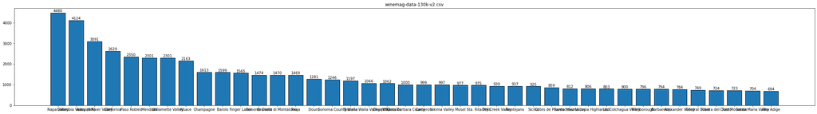

```python
whole_data_after_fill_2 = []
for current_file in file_path_arr:
        whole_data_after_fill_2.append(pd.read_csv(current_file, low_memory=False))

attribute = attributes_150[7]
figure_by_attribute(0, attribute, whole_data_after_fill_2)
```

如下所示：输出处理后region_1缺失的行title，可以看到这些属于不规范的标题，既没有用括号，也没有用年份标注region_1信息。

这些数据暂时不做进一步处理。

```python
data = pd.read_csv(file_path_arr[0], keep_default_na=False, low_memory=False)
index_nan = data[data[attribute_7] == ''].index
print(index_nan)
for i in index_nan:
    title = data.loc[i, attributes_130[11]]
    print(title)
```

```
Int64Index([  6184,  32103,  33554,  33563,  41858,  43542,  67610,  91569,
            103322, 107070, 111234, 114629],
           dtype='int64')
Medici Ermete NV Lambrusco I Quercioli Secco Lambrusco
Borgoluce NV Gaiante Glera
Sorelle Bronca NV Brut Glera
Borgoluce NV Gaiante Glera
Le Vigne di Alice NV Fondo Glera
New Age NV Sweet Gold Sparkling
Rivetto NV Nebbiolo
New Age NV Brut Sparkling
Rinaldini NV Lambrusco
Cinder NV Cabernet Sauvignon 67% Merlot 19% Malbec 14% Red
Valentin Bianchi NV Brut Méthodo Tradicional Sparkling
La Tordera NV Brunei Brut Glera
```

2.1若小粒度的信息存在，大粒度的信息缺失，那么利用小粒度的信息对大粒度的缺失值进行补充；

因为两个数据集属性几乎相同，并且可能存在交集，因此利用已有的数据建立数据字典，从而对缺失数据进行补充。

首先使用winery对region_2进行补充：

```python
def build_dict(key, value):
    dict_ = dict()
    for current_file in file_path_arr:
        data = pd.read_csv(current_file, keep_default_na=False, low_memory=False)
        index_key = data[data[value] != ''].index
        for i in index_key:
            key_ = data.loc[i, key]
            if key_ not in dict_:
                dict_[key_] = data.loc[i, value]
    return  dict_

winery_region_2_dict = build_dict(attribute_10, attribute_8)
```

```python
def fill_from_dict(current_file, dict_, key, value):
    print("current file name: ", current_file)
    cnt = 0
    data = pd.read_csv(current_file, keep_default_na=False, low_memory=False)
    index_key = data[data[value] == ''].index
    print(index_key)
    for i in index_key:
        key_ = data.loc[i, key]
        if key_ in dict_:
            data.loc[i, value] = dict_[key_]
            # print(key_, dict_[key_])
        else:
            cnt += 1

    print("There'are " + str(cnt) + "keys don't exist.")
    data.to_csv(current_file, index = False)
```

```python
fill_from_dict(file_path_arr[0], winery_region_2_dict, attribute_10, attribute_8)
```

```
current file name:  winemag-data-130k-v2.csv
Int64Index([     0,      1,      3,      6,      7,      8,      9,     11,
                13,     15,
            ...
            129896, 129897, 129898, 129899, 129901, 129902, 129903, 129905,
            129906, 129907],
           dtype='int64', length=76429)
There'are 76429keys don't exist.
```

```python
fill_from_dict(file_path_arr[1], winery_region_2_dict, attribute_10, attribute_8)
```

```
current file name:  winemag-data_first150k.csv
Int64Index([     1,      4,      5,      6,      7,     10,     13,     17,
                18,     21,
            ...
            150915, 150916, 150917, 150918, 150919, 150920, 150921, 150922,
            150923, 150924],
           dtype='int64', length=89972)
There'are 88779keys don't exist.
```

可以看到，有些key是不存在的，本身无法通过winery来获取region_2的信息。

查看补充后的region_2数据：

```
current file name:  winemag-data-130k-v2.csv
NaN                        76429
Central Coast              11276
Sonoma                      9610
Columbia Valley             8173
Napa                        7045
Willamette Valley           3656
California Other            2939
Finger Lakes                1777
Sierra Foothills            1551
Napa-Sonoma                 1209
Central Valley              1102
Mendocino/Lake Counties      941
Southern Oregon              918
Oregon Other                 755
North Coast                  723
Long Island                  682
Washington Other             601
South Coast                  288
New York Other               233
Name: region_2, dtype: int64
```

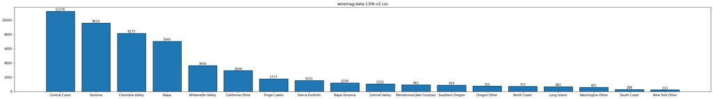

```python
whole_data_after_fill_3 = []
for current_file in file_path_arr:
        whole_data_after_fill_3.append(pd.read_csv(current_file, low_memory=False))

attribute = attributes_150[8]
figure_by_attribute(0, attribute, whole_data_after_fill_3)
```

```
current file name:  winemag-data_first150k.csv
NaN                        88779
Central Coast              13251
Sonoma                     11457
Napa                        9248
Columbia Valley             9180
California Other            3635
Willamette Valley           3278
Mendocino/Lake Counties     2395
Sierra Foothills            1673
Napa-Sonoma                 1652
Finger Lakes                1511
Central Valley              1141
Long Island                  771
Oregon Other                 672
Southern Oregon              663
North Coast                  633
Washington Other             632
South Coast                  205
New York Other               149
Name: region_2, dtype: int64
```

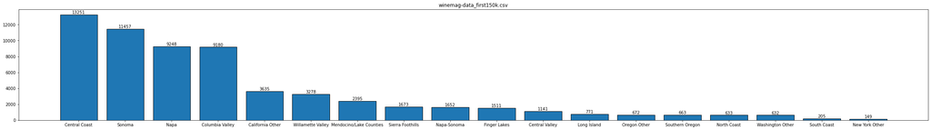

```python
figure_by_attribute(1, attribute, whole_data_after_fill_3)
```

2.2使用winery对region_1进行补充：

```python
winery_region_1_dict = build_dict(attribute_10, attribute_7)
```

```python
fill_from_dict(file_path_arr[0], winery_region_1_dict, attribute_10, attribute_7)
```

```
current file name:  winemag-data-130k-v2.csv
Int64Index([  6184,  32103,  33554,  33563,  41858,  43542,  67610,  91569,
            103322, 107070, 111234, 114629],
           dtype='int64')
There'are 2keys don't exist.
```

```python
fill_from_dict(file_path_arr[1], winery_region_1_dict, attribute_10, attribute_7)
```

```
current file name:  winemag-data_first150k.csv
Int64Index([   367,   1032,   1639,   4640,   4862,   8131,   8348,   8365,
              9368,  10495,
            ...
            150200, 150201, 150239, 150248, 150256, 150296, 150323, 150363,
            150371, 150373],
           dtype='int64', length=1369)
There'are 1369keys don't exist.
```

再次查看补充后的region_1:

130k的数据从只有2个空缺；150k的数据只有1369个空缺。

```
current file name:  winemag-data-130k-v2.csv
Napa Valley                 4480
Columbia Valley (WA)        4124
Russian River Valley        3091
California                  2629
Paso Robles                 2350
                            ...
Moscato di Pantelleria         1
Geelong                        1
Criots-Bâtard-Montrachet       1
Mendocino-Amador               1
Payoya Negra Red               1
Name: region_1, Length: 1817, dtype: int64
```

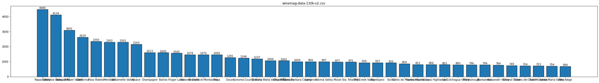

```python
whole_data_after_fill_4 = []
for current_file in file_path_arr:
        whole_data_after_fill_4.append(pd.read_csv(current_file, low_memory=False))

attribute = attributes_150[7]
figure_by_attribute(0, attribute, whole_data_after_fill_4)
```

```
current file name:  winemag-data_first150k.csv
Napa Valley                       6253
Columbia Valley (WA)              4980
Mendoza                           3612
Russian River Valley              3580
California                        3507
                                  ...
Vin de Pays de l'Ile de Beauté       1
Vallée du Paradis                    1
Loazzolo                             1
Gambellara Classico                  1
Mâcon-Milly Lamartine                1
Name: region_1, Length: 1516, dtype: int64
```

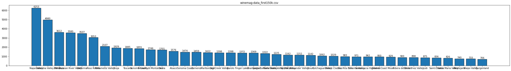

```python
figure_by_attribute(1, attribute, whole_data_after_fill_4)
```

### 3.designation属性的处理，为标称属性。

该属性和variety之间存在多对多的关系，仔细看了一下数据名称，应该是指酒的名字，同一款酒可能使用不同种类的葡萄，一种葡萄会被多款酒使用；同时，一个庄园可能生产多款酒。关联关系不强，因此在此不做处理。

```
current file name:  winemag-data-130k-v2.csv
NaN                    37454
Reserve                 2006
Estate                  1321
Reserva                 1259
Riserva                  698
                       ...
Calistoga Estate           1
Le Chatelet                1
Clarete                    1
Cuvée di Gabry Rosé        1
Garnacha Cabernet          1
Name: designation, Length: 37955, dtype: int64
```

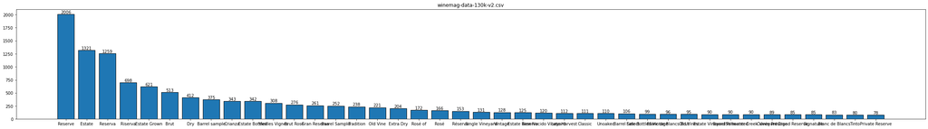

```python
attribute = attributes_150[3]
figure_by_attribute(0, attribute, whole_data_after_fill_4)
```

```
current file name:  winemag-data_first150k.csv
NaN                        45735
Reserve                     2752
Reserva                     1810
Estate                      1571
Barrel sample               1326
                           ...
Particella 68 Brut             1
Rjgialla                       1
Beckstoffer - Clone Six        1
Le Paradou                     1
Freakshow                      1
Name: designation, Length: 30619, dtype: int64
```

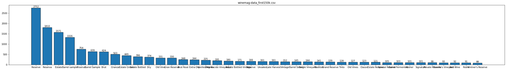

```python
figure_by_attribute(1, attribute, whole_data_after_fill_4)
```

### 4.points属性的处理，为数值属性。

```python
def figure_of_time_spent(current_data, i):
    print('五数概括：')
    print('Min:', np.min(current_data))
    print('Q1:', np.percentile(current_data, 25))
    print('Q2:', np.percentile(current_data, 50))
    print('Q3:', np.percentile(current_data, 75))
    print('Max:', np.max(current_data))
    col = np.array(current_data)
    plt.figure(figsize=(10, 3))
    plt.boxplot(col, notch=False, vert=False)
    plt.xlabel('time spent of ' + file_path_arr[i])
    plt.show()
    outlier = np.percentile(col, 75) + (np.percentile(col, 75) - np.percentile(col, 25)) * 1.5
    print("离群点：", outlier)
```

```
五数概括：
Min: 80
Q1: 86.0
Q2: 88.0
Q3: 91.0
Max: 100
```

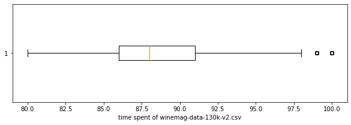

```
离群点： 98.5
```

```python
figure_of_time_spent(np.array(whole_data_after_fill_4[0][attributes_150[4]]), 0)
```

```
五数概括：
Min: 80
Q1: 86.0
Q2: 88.0
Q3: 90.0
Max: 100
```

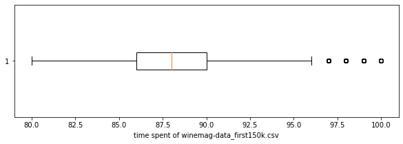

```
离群点： 96.0
```

```python
figure_of_time_spent(np.array(whole_data_after_fill_4[1][attributes_150[4]]), 1)
```